# ${\text{MATH 191T Final Report}}$

# ${\text{Data Stuctures}}$

# $${\color{purple}{\scriptsize{\text{Dairah Loren Heinz}}}}$$

$$\color{purple}{\small{\text{MATH 191T}}}$$$$\color{purple}{\small{\text{December 10, 2020}}}$$

${\text{Please note that I primarily used CO (Collaboratory)}}$

If any links do not work or you would like to contact me, please feel free to [email me](https://mail.google.com/mail/u/0/?view=cm&fs=1&tf=1&source=mailto&to=dairahheinz001@mail.fresnostate.edu), or drop a comment on this notebook.

If there are any issues with the images, it may help to have the link to the file in my drive where they are saved: [Structure Diagrams](https://drive.google.com/drive/folders/11Y6XFlqNFMvLrY1tNkCzi-nCWnlBzhgp?usp=sharing)

## $\bf\text{Contents}$

1. $\color{black}{\bf\text{Introduction}}$
   - $\color{black}{\text{Questions}}$
   - $\color{black}{\text{Attribute Table}}$
2. $\color{black}{\bf\text{Methods and Results}}$
   - $\color{black}{\text{Node Class}}$
   - $\color{black}{\text{Single Linked List(SLL)}}$
   - $\color{black}{\text{Doubly Linked List(DLL)}}$
   - $\color{black}{\text{Circularly Linked List(CLL)}}$
   - $\color{black}{\text{Net Structure}}$
   - $\color{black}{\text{Tree}}$
3. $\color{black}{\bf\text{Discussion}}$
   - $\color{black}{\text{Additional Questions}}$
4. $\color{black}{\bf\text{References}}$
   - $\color{black}{\text{Formal Citations}}$

```python
from IPython.display import Image, display;# for displaying the images
import pandas as pd
import math
#import IPyPlot
#ipyplot.plot_images([a,b,c,d], max_images=20, img_width=150)
```

# $\text{Introduction}$

$\text{(Return to Contents)}$

Data structures are an essential aspect of computer science and math, particularly applied math. At Fresno State, math and computer science majors are currently required to take at least CSCI 40. In this class we are introduced to the basic concepts needed for programming in C++, such as function and classes, and the concepts needed to understand those as well. If you are an applied mathematics student, you are currently required to also take CSCI 41. In this class, we expand the idea of classes to linked lists. In this project, I will discuss some of these concepts and they would be implemented in Python (notebook) rather than a raw C++ environment. From what I have learned from taking CSCI 41, there are several basic data structures that can be utilized to create bigger, compound, and more complex structures. In this project, I will introduce a few of these.

It may also be valuable to note that CSCI 41 is a required class for computer science majors as well. This notebook will address the following questions regarding data structures:

- What are linked lists?
- What kind of linked lists are there?
- How can we visualize these structures?
- How do we implement these structures in python, Jupyter Notebooks, or collaboratory?
- What does a combined, or net,as I called it, structure look like? Here, I have also included a table on what attributes will be used in each class.

| Structure Attributes: | Data | Next | Prev | Up | Down | Left | Right |
| --- | --- | --- | --- | --- | --- | --- | --- |
| Single Linked List (SLL) | $\checkmark$ | $\checkmark$ | ✗ | ✗ | ✗ | ✗ | ✗ |
| Double Linked List (DLL) | $\checkmark$ | $\checkmark$ | $\checkmark$ | ✗ | ✗ | ✗ | ✗ |
| Circularly Linked list(CLL) | $\checkmark$ | $\checkmark$ | $\checkmark$ | ✗ | ✗ | ✗ | ✗ |
| Net Structure | $\checkmark$ | $\checkmark$ | $\checkmark$ | $\checkmark$ | $\checkmark$ | $\checkmark$ | $\checkmark$ |
| Tree Structure | $\checkmark$ | ✗ | ✗ | ✗ | ✗ | $\checkmark$ | $\checkmark$ |

In other words, where there is a $\checkmark$, the class will contain that attribute and where there is an ✗, the class does not require or use that attribute. This table is intended to summarize each class to help create a better overall understanding of what each class requires. Along with the table, I would like to note that there are many different ways to implement the concepts for these classes, but the purpose of this project is to share my implementation of these concepts to help create a better understanding of the concepts as a whole.

The next section (Methods and Results), includes **AN** implementation of the Node class and the structures discussed in the table above. In order to build off of what we have learned in class, this implementation will utilize classes and operator overloading.

# $\text{Methods and Results}$

$\text{(Return to Contents)}$

To start, we take a look at the most fundamental class, the Node class. This class will serve as a sort of basis for all of the classes. In other words, all of the structures are composed of nodes, each with different configurations, or structures.

I would also like to reiterate that there are many different ways to achieve the same operations and highly recommend exploring these concepts with your own implementation and preferences.

## $\text{Node Class}$

$\text{(Return to Contents)}$

Nodes, as indicated below, have attributes data, index, next, prev, up, down, right, and left. The directionally named attributes will serve as the 'arrows', or connections, between nodes.

Also, please note that I will be using operator overloading due to its convenient and comprehensible nature.So that we can use Node objects for all of the structures, it will be initialized with all possibly used attributes, using `__init__` and so that we can print each node with the index and the data, we will utilize the `__str__` overloader.

```python
class Node:
   '''Object with attributes:
   data, index, next, prev, up, down, right, and left.'''
   # if you use index, make sure that it is accounted for:
   #  - incremented appropriately when adding
   #  - decremented appropriately when subtracting
   def __init__(Node,data=None,index=0,Next=None,prev=None,up=None,down=None,right=None,left=None):
       Node.data  = data ;#int,float, string, or some other object (theoretically)
       Node.next  = Next ;
       Node.prev  = prev ;
       Node.up    = up   ;
       Node.down  = down ;
       # mainly for trees and net structure
       Node.left = left;
       Node.right = right;
       Node.index = index;
   def __str__(Node):# Node is used in replacement of self here
       if type(Node.data)==(int or float):# special instructions when Node is a number
           return '(%.d,%.d)' % (Node.index,Node.data)
       else:
           return str((Node.index,Node.data))
```

```python
#?Node# if you need a reminder
```

```python
print(str(None))
print(Node())
print(Node('Dairah loves nodes!',2))
print(Node(0,1))
print(Node(None,1))
```

```
None
(0, None)
(2, 'Dairah loves nodes!')
(1,0)
(1, None)
```

$\large\text{For the rest of the classes, we will be implementing conceptualized data structures as code.}$

To assist in the conceptualization side of data structures, I have created the diagrams, as imported below, using Mathematica. Also, most of the structures will have notable similarities.

```python
# k ='' # for jyupter notbooks
k = '/content/drive/Shareddrives/Me, Myself and I/Year 3/Semester 5/MATH 191T(programming)/PROJECTS/FINAL/DIAGRAMS/'
a=Image(filename=k+'SingleLinkedList.png',width = 500)
b=Image(filename=k+'DoublyLinkList.png',width = 550)
c=Image(filename=k+'CircularlyLinkedList.png',width = 300)
d=Image(filename=k+'CombinedStucture.png',width = 250)
e=Image(filename=k+"TREE.png",width = 550)
f=Image(filename=k+"HorizontalCombined.png",width = 550)
g=Image(filename=k+"HandV (1).png",width = 550)
#display(a,b,c,d)
```

$\underline{\large\text{To make the diagrams, as displayed in each structure section, I used mathematica.}}$ $$\text{If you would like to see the what I did there here is the link:}$$ [$$\text{Linked List Structure Diagrams in Mathematica}$$](https://www.wolframcloud.com/obj/f2523128-33ee-46cb-a3fd-945b561dbbbc)

For the overall method of the classes, I started with the basis that all of the classes would depend on the Node class. This class created the object that was declared with data,index, next, prev, up and down attributes. Now, not all of the classes require all attributes.

Then for each class, I created functions that allowed me to appropriately print, add, in some subtract from the list, and more. I did utilize operator overloading to do this in some parts. There are other ways to do it without using overloading, but overloading does seem to be a lot cleaner than other methods.

## $\text{Single Linked List}$

$\text{(Return to Contents)}$

Single linked lists are the next most basic, or fundamental, structures to the node. They are connected in one direction with a front node. This can be thought of as a one way structure.

```
Single linked List:
```

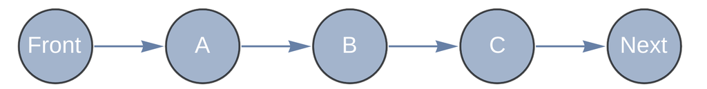

```python
print("Single linked List:");    display(a)
```

As you can see from the diagram above, this structure, or list, is composed of nodes attached in a sequential and singularly directional fashion. In other words, the nodes are linked to each other in only one direction.

```python
class SLL:# single linked list
   '''A list composed of nodes, each with a single or one way facing arrow.
   Ex.: (Front) -> (A) -> (B) -> (Next)'''
   def __init__(SLL,Front=None,icount=0):#last and Next are used interchangeably here
       Front = Node()
       SLL.front = Front;
       SLL.last = Front; # to start, but it will move as nodes are added
       SLL.icount = icount;
       #Front=None
   def __str__(SLL):# stores all of the nodes as a string to be printed
       temp = SLL.front
       k = ''
       while type(temp)==Node:# !=None didn't work
           k= k+str(temp)
           if type(temp.next)==Node:# !=None didn't work
               k = k+'->'
           temp = temp.next
       return k
   def __add__(SLL,data):
       i = SLL.icount
       temp = SLL.last
       if type(data)!=Node:
         temp.next = Node(data,i+1)
       if type(data)==Node:
         temp.next = data;
         temp.next.index = i+1# always account for the index
       SLL.last = temp.next;
       SLL.icount+=1
       return SLL # so that we can add more than one node in each line when we use the + operator
   def add(SLL,data):# should I make this data able to be a node
       i = SLL.icount# account for index
       temp = SLL.last
       if type(data)!=Node:
        temp.next = Node(data,i+1)
       if type(data)==Node:
        temp.next = data;
        temp.next.index = i+1
       SLL.last = temp.next;
       SLL.icount+=1
       return SLL# so that we can more than one node in each line when add is called
   # add() can not be called like: sll.add('#')+sll.add('other#'),
   #                   instead do: sll.add('#'),sll.add('other#')
   def at(SLL,index=None,data=None):# clarify what you are searching by
     temp = SLL.front
     # we need to know what the node is being searched by
     if index!=None and data!=None:
       return "Do not search by index and data at the same time."
     elif index!=None or data!=None:
       while temp!=None:
         if temp.index==index or str(temp.data)==str(data):
            break;
         else:
           temp = temp.next
       if temp==None:
         if index!=None:
           return "No node in the list has index = "+str(index)+"."
         if data!=None:
           return "No node in the list has data = "+str(data)+"."
       else:
         return temp;
     else:
       return "No index or data given, there is nothing to search for.";
   # so that we can print the list as a more organized table(looks nicer)
   def table(SLL):
     data = []
     temp = SLL.front
     while temp!=None:
       data.append([temp.data])
       temp = temp.next
     return pd.DataFrame(data,columns=["Data"])
```

For the sake of simplicity I explained most of what and why I did what I did below using comments.

```python
print(type(Node())==Node) # I used this idea to check that objects are Nodes as in the class definition above
print(type(SLL)!=Node)
# print(type(SLL)==CLL) # this can be uncommented if CLL is defined/declared already.
# the purpose of the line above is to check that the type function of SLL will not yield CLL...
#... or that SLL and CLL are not the same.
```

```
True
True
```

```python
sll = SLL()
sll.front.data = 500
sll.add('You can do strings too!');
sll.add(100)
sll+'this too'
sll+Node(200)+'oh, yeah and this way too'+400
sll.add(Node(1))+1,sll.add(2)# when using the .add() function, calls must be seperated by a line or comma
print('1)LIST:')
display(sll.table())
print('3)',sll.at(1),'\n4)',sll.at(sll.last.index+1))
print('5)',sll.last.index)
# print(s.last)
```

```
1)LIST:
```

|  | Data |
| --- | --- |
| 0 | 500 |
| 1 | You can do strings too! |
| 2 | 100 |
| 3 | this too |
| 4 | 200 |
| 5 | oh, yeah and this way too |
| 6 | 400 |
| 7 | 1 |
| 8 | 1 |
| 9 | 2 |

```
3) (1, 'You can do strings too!')
4) No node in the list has index = 10.
5) 9
```

```python
#?DataFrame # if you want to know uncomment this
```

```python
# You can search by index or by data
 # here are some different possible cases
# Also, because it does return the node,
 # you can still access the data and the index
print(sll.at(data = "this too").data)
print(sll.at(data = 150))
print(sll.at(index = 4))
print(sll.at(index = 12))
print(sll.at())
print(sll.at(index=0,data=0))# either or, not both
```

```
this too
No node in the list has data = 150.
(4,200)
No node in the list has index = 12.
No index or data given, there is nothing to search for.
Do not search by index and data at the same time.
```

```python
s = SLL()
# this is to show that you can create mutiple instances
# of a SLL without it being duplicated
print(s.front.data,s.front.index)
print(s.front)
print(SLL().front.next)
# checks to ensure that sll and s do not have a front
print(s.front==sll.front)
```

```
None 0
(0, None)
None
False
```

## $\text{Doubly Linked List}$

$\text{(Return to Contents)}$

```
Double Linked List:
```

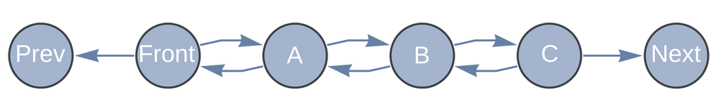

```python
print("Double Linked List:");    display(b)
```

```python
class DLL:# doubly linked list
   '''A list composed of nodes, each with two one-way facing arrows opposite in direction to each other.
   Ex.: (Front) <=> (A) <=> (B) <=> (Next)'''
   def __init__(DLL,Front=None,icount=0):#last and Next are used interchangeably here
       Front = Node()
       #Last = Front;
       DLL.front = Front;
       DLL.front.prev = None # there is nothing left of last
       #DLL.last = Last;
       DLL.last = Front;
       DLL.last.next  = None # there is nothing right of last
       DLL.front.next = DLL.last# Front->Last to start
       DLL.last.prev  = DLL.front# Front<-Last to start
       # also the last and front node are the same Node to start
       #DLL.front = DLL.last # is there a case where this is needed??
       DLL.icount = icount;
   def __str__(DLL):# stores all of the nodes as a string to be printed
       temp = DLL.front
       k = ''
       while type(temp)==Node:
           k= k+str(temp)
           if type(temp.next)==Node:
               k = k+'<=>'
           temp = temp.next
       return k
   def __add__(DLL,data):
     i = DLL.icount
     temp = DLL.last
     temp.next = Node(data,i+1)
     temp.next.prev = temp;
     DLL.last = temp.next;
     DLL.icount+=1
     return DLL # so that we can add more than one node in each line
   def add(DLL,data):#addNode to the 'end'(the far right) of the list
      i = DLL.icount
      temp = DLL.last
      temp.next = Node(data,i+1)
      temp.next.prev=temp
      DLL.last = temp.next
      DLL.icount+=1
      return DLL
   def at(DLL,index=None,data=None):# clarify what you are searching by
     temp = DLL.front
     if index!=None and data!=None:
       return "Do not search by index and data at the same time."
     elif index!=None or data!=None:
       while temp!=None:
         if temp.index==index or str(temp.data)==str(data):
            break;
         else:
           temp = temp.next
       if temp==None:
         if index!=None:
           return "No node in the list has index = "+str(index)+"."
         if data!=None:
           return "No node in the list has data = "+str(data)+"."
       else:
         return temp;
     else:
       return "No index or data given, there is nothing to search for.";
   def table(DLL):
     data = []
     temp = DLL.front
     while temp!=None:
       data.append([temp.data])
       temp = temp.next
     return pd.DataFrame(data,columns=["Data"])
# if I add a subtract or delete function I will have to take care of changing all of the indexes respectively
```

```python
dll = DLL()
dll.front.data=500
#print(dll)
dll.add('You can do strings too!');
dll.add(100)
dll+200+300+'ooh'
#print(dll.front,dll.last.prev,dll.last)
print('LIST:')
display(dll.table())
print('---or---\n|'+str(dll)+'|\n\nIndex count: '+str(dll.icount))
```

```
LIST:
```

|  | Data |
| --- | --- |
| 0 | 500 |
| 1 | You can do strings too! |
| 2 | 100 |
| 3 | 200 |
| 4 | 300 |
| 5 | ooh |

```
---or---
|(0,500)<=>(1, 'You can do strings too!')<=>(2,100)<=>(3,200)<=>(4,300)<=>(5, 'ooh')|

Index count: 5
```

```python
# you can search by index or by data
 # here are some different possible cases
print("Using real data:\n ",dll.at(data = 100))
print("Using nonexistent data:\n ",dll.at(data = 150))
print("Using a real index:\n ",dll.at(index = 4))
print("Using a nonexistent index:\n ",dll.at(index = 12),'\n')
print(dll.at(),'\n')
print(dll.at(index=0,data=0))# either or, not both
```

```
Using real data:
  (2,100)
Using nonexistent data:
  No node in the list has data = 150.
Using a real index:
  (4,300)
Using a nonexistent index:
  No node in the list has index = 12.

No index or data given, there is nothing to search for.

Do not search by index and data at the same time.
```

```python
d=DLL();
# this is to show that you can create mutiple instances
# of a DLL without it being duplicated
print(d.front.data,sll.front.index)
print(d.front)
print(DLL().front.next,DLL().front.next)
# checks to ensure that D and dll do not share a front
print(d.front==dll.front)
```

```
None 0
(0, None)
(0, None) (0, None)
False
```

You may notice that I reused some of the code between CLL and DLL. This is because the only difference is making sure that there is a connection in both directions. This is of primary concern when adding or subtracting nodes from a list.

## $\text{Circularly Linked List}$

$\text{(Return to Contents)}$

```
Circularly Linked List:
```

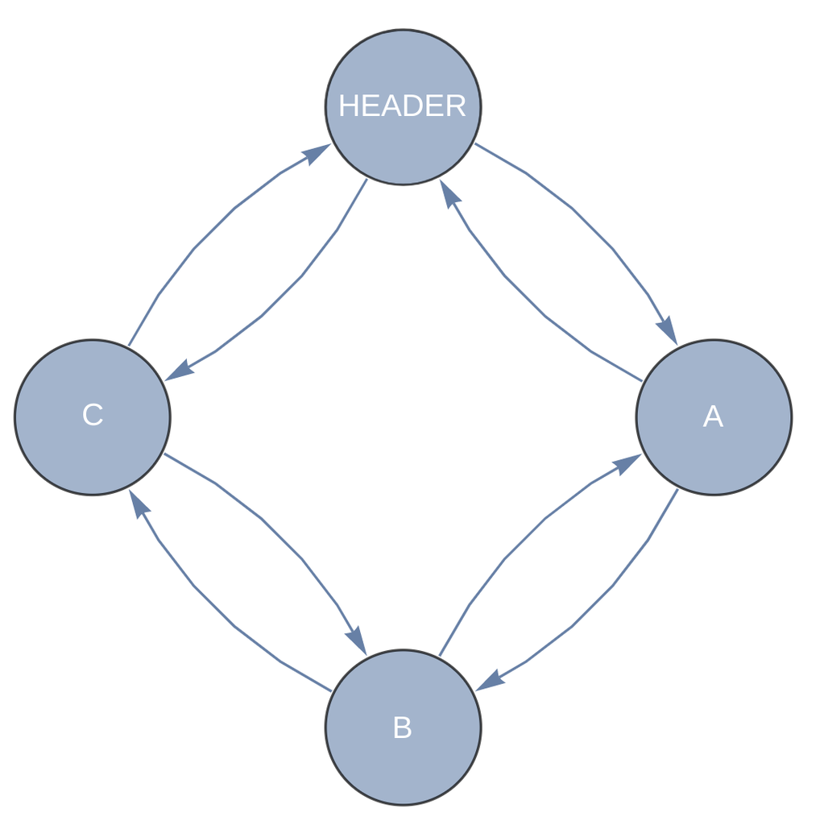

```python
print("Circularly Linked List:");display(c)
```

```python
class CLL:# circularly linked list
    '''A list composed of nodes, each with two one-way facing arrows, oposite in direction to each other,
    where the last node is doubly connected to the header.
    Ex.: (Header) <=> (A) <=> (B) <=> (C or Header prev)'''
    def __init__(CLL,header=None,icount=0):#last and Next are used interchangeably here
        header = Node()
        CLL.header = header;
        CLL.header.next = CLL.header
        CLL.header.prev = CLL.header
        #header = CLL.header # will this even work??
        CLL.icount = icount
    def __str__(CLL):# stores all of the nodes as a string to be printed
        temp = CLL.header.next#could make this header.prev if prev set up
        k = '|-->'+str(CLL.header)+'\n|      ^         \n|      |         \n|      v         \n';
        while type(temp)==Node and temp!=CLL.header:
            k+='|'
            if temp.next==CLL.header:
              k+='-->'
            if temp.next!=CLL.header:
              k+='   '
            k+=str(temp)+'\n'
            if type(temp.next)==Node:
              if temp.next!=CLL.header:
                k +='|      ^         \n|      |         \n|      v         \n'
            temp = temp.next
        # the if statement below is mainy for the net structure
        if CLL.header.next==CLL.header or CLL.header.data==None:
          k = str(CLL.header)
        return k
    # you can add a node or a string. either way works
    def __add__(CLL,data):
      i = CLL.icount
      if (type(data)!=Node):
        nn= Node(data,i+1)
      if (type(data)==Node):
        nn = data;
        nn.index = i+1
      if CLL.header.data!=None:
        k = CLL.header.prev
        k.next = nn; k.next.prev = k
        nn.next = CLL.header; CLL.header.prev = nn;
        CLL.icount+=1
      else:
        CLL.header.data = nn.data
        CLL.icount-=1;
        del nn;#nn does not need to exist if header is the only node in the CLL
      return CLL # so that we can add mutiple nodes at a time
    def __sub__(CLL,data):
      if type(data)==Node:# so that we can add it as a node or a string or number
        data = data.data;
      # deletes the most recent instance of node with node.data=data
      # starts with the header.prev
      temp = CLL.header.prev;
      while temp!=CLL.header:
        if temp.data==data:
          temp.next.prev = temp.prev;
          temp.next.prev.next = temp.next;
          del temp
          temp = None;# if you comment this out you will see why its necessary
          CLL.icount-=1
          break;
        temp = temp.prev;
      if temp==CLL.header:
        if temp.data==data:
          temp = temp.next
          CLL.header.data = CLL.header.next.data;
          CLL.header.next = CLL.header.next.next;
          CLL.header.next.prev = CLL.header;
          CLL.icount-=1
          del temp;
          temp=None
          #return CLL;
        #elif temp!=None:
          #print(str(data) + " has not been found in any node in the list.\n")
          #return;
          #break;
          #temp=None
      # make sure all of the indexes are correct;
      iFix = CLL.header.next;
      i=1;
      while iFix!=CLL.header:
        iFix.index=i;
        i+=1;
        iFix = iFix.next;
      return CLL;
    # make a function that deletes all instances of a data
    def add(CLL,data):#addNode to the 'end'(the far right) of the list
        i = CLL.icount
        #temp = CLL.header
        #while type(temp.next)==Node:
          #temp = temp.next
        nn= Node(data,i+1)
        k = CLL.header.prev
        k.next = nn; k.next.prev = k
        nn.next = CLL.header; CLL.header.prev = nn;
        #nn.next.prev=nn
        #nn.prev.next=nn
        #CLL.last = temp.next
        CLL.icount+=1
        return CLL # IF THERE ARE ANY ISSUES CHECK HERE
    def deleteAll(CLL,data):# to delete all occurances of a data member
      if type(data)==Node:
        data = data.data;
      elif type(data)==list or type(data)==tuple:
        for x in range(len(data)):
          if CLL.header.data==data[x]:
            CLL-data[x];
          temp = CLL.header.next;
          while temp!=CLL.header:
            CLL-data[x];
            #continue#do not uncomment I belive it causes infinite loop
            temp = temp.next;
      else:
        if CLL.header.data==data:
          CLL-data;
        temp = CLL.header.next;
        while temp!=CLL.header:
          CLL-data;
          #continue#do not uncomment I belive it causes infinite loop
          temp = temp.next;
    def at(CLL,index):
      iN = CLL.header
      if index<=CLL.icount:# if the index being searched for is within bounds
        while iN.index!=index:
          iN = iN.next
      if index!=0 and iN==CLL.header:
        return ' Node of index '+str(index)+' does not exist in this list.'
      else:
        return iN;
```

```python
#print(CLL().header)
# you can add as a node, string, or number
# you can subract the most recent occurance of a data value
cll = CLL()
cll.header.data='Header'
cll.add('a')
cll.add('b')
cll.add('c')
#print(cll)
cll.add('d')
# you can add multiple nodes at a time in the following two ways:
cll+'e'+'f'
cll+Node('g')+Node('h')
#print(cll)
#cll-'Header'-'a'-'b'
cll-'C'# if it does not exist in the list there is nothing to delete
# cll-'A'-'d'+'numbers:'+Node('i')+1+1+'h'
# you can subtract all of each occurance of a data
# cll.deleteAll(1)
# cll.deleteAll(('h',1,'f','e'))# can delete all of mutiple inpouts
k = 4
print('cll.at('+str(k)+'):'+str(cll.at(k)))
# print(cll.at(4).data)# for just the data
print(cll)
# print(cll-1)#you can subtract as a number
```

```
cll.at(4):(4, 'd')
|-->(0, 'Header')
|      ^
|      |
|      v
|   (1, 'a')
|      ^
|      |
|      v
|   (2, 'b')
|      ^
|      |
|      v
|   (3, 'c')
|      ^
|      |
|      v
|   (4, 'd')
|      ^
|      |
|      v
|   (5, 'e')
|      ^
|      |
|      v
|   (6, 'f')
|      ^
|      |
|      v
|   (7, 'g')
|      ^
|      |
|      v
|-->(8, 'h')
```

## $\text{Net Stucture}$

$\text{(Return to Contents)}$

##### $Note:$ You can visualize this stucture horizontally and vertically, I tend to prefer vertically.

```
Net Stucture:
```

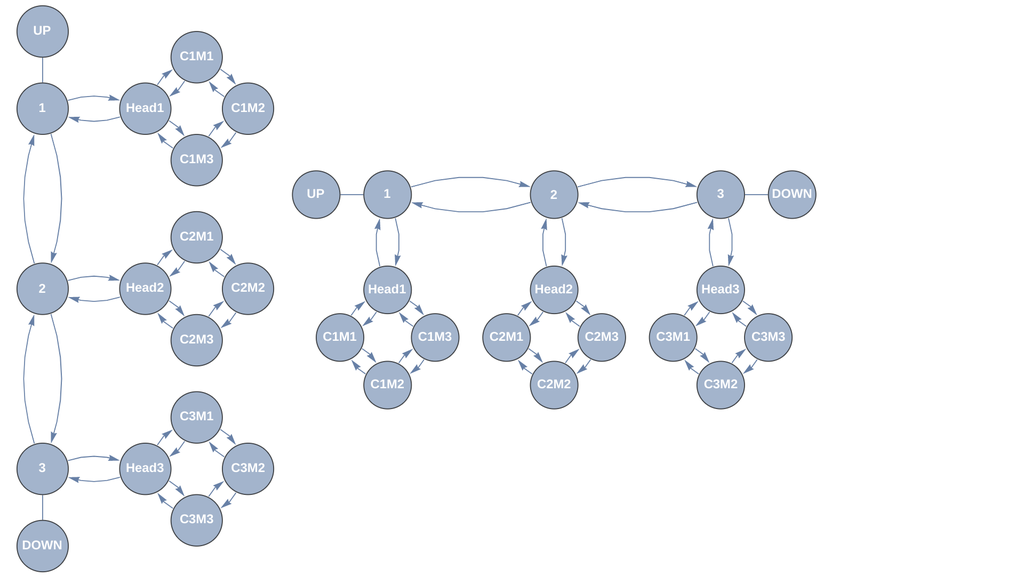

```python
g.width = 800
print("Net Stucture:");          display(g);#display(d,f);
#print(d.width,d.height,f.width,f.height)
#print(g.height,g.width)
```

```python
class Net:# single linked list
    '''Structure composed of a doubly linked list where each node is doiblt linked to the header of a doubly linked list.'''
    def __init__(Net,top=None,icount=0):#,CLL=CLL()):#last and Next are used interchangeably here
        top = Node()
        Net.top          = top;
        Net.bottom       = top # to start header and bottom are in the same place

        Net.top.up       = None
        Net.bottom.down  = None;

        Net.icount = icount;
        Net.top.index = 0;
        # to access the CLL connected to the category
        # if you prefer and/or are actually dealing with netflix type
        # structure, you cauld call it movies instead
        Net.top.CLL = CLL(header=Node())
        # making sure to account for the index
        Net.top.CLL.icount+=1
        Net.bottom.CLL = Net.top.CLL;
        Net.top.right = Net.top.CLL.header;
        Net.bottom.right = Net.bottom.CLL.header;
    def __add__(Net,category):
      if type(category)==Node:
        category = category.data
      else:
        if Net.top.data == None:# and Net.top.down == None:# do I need the stuff after the and here?
          Net.top.data = category;
        else:
          # make the new category
          Net.bottom.down = Node();
          Net.bottom.down.data = category
          Net.icount+=1;
          Net.bottom.down.index = Net.icount;
          # make and attach a CLL to the category
          Net.bottom.down.CLL = CLL(header=Node())
          Net.bottom.down.CLL.icount+=1
          # make the CLL attribute the same as the right attribute
          Net.bottom.down.right = Net.bottom.down.CLL.header;
          Net.bottom.down.right.left = Net.bottom.down;
          # make the up a down connections between the previous bottom and the new bottom
          Net.bottom.down.up = Net.bottom;
          # move the Net.bottom label to the new bottom
          Net.bottom = Net.bottom.down;
          #Net.bottom.down = None;
      return Net;
    def __str__(Net):
      t = Netflix.top
      k=''
      # print('Categories:')
      k +='Categories:\n'
      while t!=None:
        #print(str(t.data)+':')
        k+=str(t.data)+':\n'
        #print(t,':')# if you want t as the whole node
        #print(t.CLL)
        k+=str(t.CLL)+"\n"
        #print("")
        t=t.down
      return k;
    def at(Net,i):
      temp = Net.top;
      if type(i)==int:
        while temp!=None:
          if (temp.index!=i):
            temp = temp.down;
          else:
            break;
        if temp!=None:
          return temp;
        else:
          return "There is no Node at index "+str(i)+" in this Net.";
      elif type(i)==str:
        while temp!=None:
          if (temp.data!=i or temp.data!=str(i)):
            temp = temp.down;
          else:
            break;
        if temp!=None:
          return temp;
        else:
          return "There is no Node with data "+str(i)+" in this Net.";
# for Netflix there are categories (DLL) that individually connect to circular linked lists full of movies. There could also be another whole layer
# when comes to movies vs shows vs documentaries vs...? what else is there in Netflix
```

### $\text{Example:}$

For the sake of understanding, I will use an example where the double linked list serves at the categories and the CLL connect to each category is a list of movies.

```python
Netflix = Net()
Netflix.top.data=None

Netflix+'Horror'+"Comedy"+"Action"+"Cartoon"+"Family"+"Musicals"

# with at, you can search by index or by category data/name
Netflix.at("Horror").CLL + "It" + "Chucky" # Node("Chucky")
# you can also add them as nodes, just like we did with CLL's
Netflix.at("Comedy").CLL+"Elf" +Node("LEGO Movie")+"Bee Movie"
Netflix.at("Action").CLL+"I am Legend" +"Fast and Furious"
Netflix.at("Cartoon").CLL+"The Croods" +"The Girnch that Stole Christmas"
#...and, if the movie is a number, you can add it without quotes :)
Netflix.at("Family").CLL+"The Grinch that Stole Christmas"+"Home Alone"+42
Netflix.at("Musicals").CLL+"Mamma Mia"+"Into the Woods"+"Matilda"+"Freaky Friday"
#i = 0;
#while i<=Netflix.icount:
  #print(Netflix.at(i));
  #i+=1;
```

```
<__main__.CLL at 0x7f8bd8d4b518>
```

```python
#print(Netflix.at(5).CLL.header.next)
k = 2
print(Netflix.at(k))
print(Netflix.at(k).right)
print(Netflix.at(k).left)# this should be none
print(Netflix.at(k).right.left)
```

```
(2, 'Action')
(0, 'I am Legend')
None
(2, 'Action')
```

```python
print(Netflix)
# there may also be ways to order them in
# alphebetical order, but I will not be visiting that topic
```

```
Categories:
Horror:
|-->(0, 'It')
|      ^
|      |
|      v
|-->(1, 'Chucky')

Comedy:
|-->(0, 'Elf')
|      ^
|      |
|      v
|   (1, 'LEGO Movie')
|      ^
|      |
|      v
|-->(2, 'Bee Movie')

Action:
|-->(0, 'I am Legend')
|      ^
|      |
|      v
|-->(1, 'Fast and Furious')

Cartoon:
|-->(0, 'The Croods')
|      ^
|      |
|      v
|-->(1, 'The Girnch that Stole Christmas')

Family:
|-->(0, 'The Grinch that Stole Christmas')
|      ^
|      |
|      v
|   (1, 'Home Alone')
|      ^
|      |
|      v
|-->(2,42)

Musicals:
|-->(0, 'Mamma Mia')
|      ^
|      |
|      v
|   (1, 'Into the Woods')
|      ^
|      |
|      v
|   (2, 'Matilda')
|      ^
|      |
|      v
|-->(3, 'Freaky Friday')
```

## $\text{Tree Structure}$

$\text{(Return to Contents)}$

### $\text{For the sake of simplicity, we will focus primarily on binary trees}$

```
Tree:
```

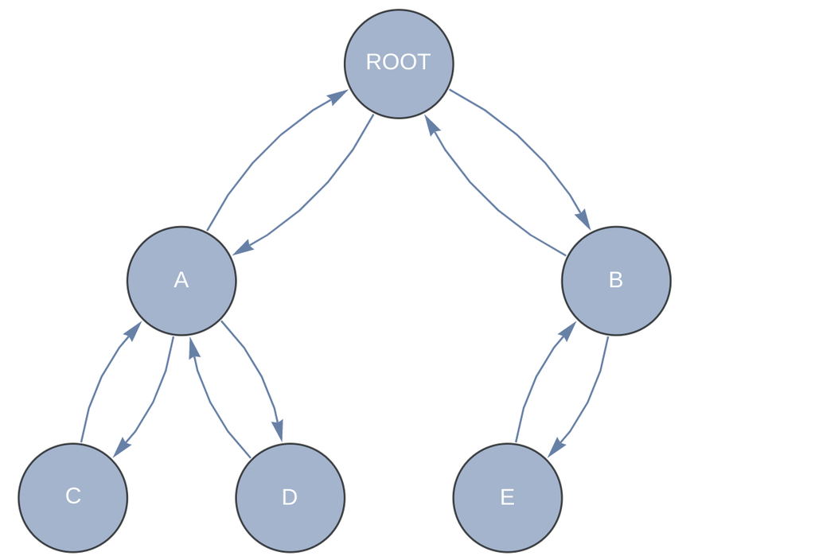

```python
e.width=400
print('Tree:');                  display(e)
```

```python
def log(b,x):
 return math.log(x,b)

def floor(x):
 return math.floor(x)

class Tree:# Binary Tree structure(special case)
  '''A list composed of nodes, each with up to two leaves, or children,
  both Nodes, and a root. Each row count occurring in multiples of 2.'''
  # for the sake of simplicity, we are going to assume each level, or row,
  # is filled before moving on to the next
  def __init__(Tree,root=None):
      Tree.root = Node();
      Tree.root.left = None;
      Tree.root.right = None;
  def getTree(Tree, root):# order not obvious, but still ordered
     # also this is a recursive function
      res = []
      if root:
          res = Tree.getTree(root.left)
          res.append(root)
          res = res + Tree.getTree(root.right)
      return res
  # this function returns an ordered vector
  def inOrder(Tree):# does not require additional argument; not recursive
    # this function returns that ordered vector to represent the tree
    tempnum = 0;
    vector = []
    r = tree.getTree(tree.root)
    for k in range(floor(log(2,len(r)))+1):# the number of levels
      for x in range(len(r)):
        if floor(log(2,(r[x].index)+1))==tempnum:
          vector.append(r[x])
      tempnum+=1
    return vector
  def __str__(Tree):# stores all of the nodes as a string to be printed
    vector = Tree.inOrder()
    k=''
    for x in range(len(vector)):
      k+=str(vector[x])
      if floor(log(2,x+1)) < floor(log(2,x+2)):
        k+='\n';
    return k
# adding and subtracting are much more difficult in this structure, but there
# there are many online resources to help you do this. For this reason, I will be
# sticking to manual insertion and no deletion
```

### Note:

`floor(log(x+1))` equates to the level the node of index x is on, given that the root is on level zero and that indexes start at 0.

```python
tree = Tree();
tree.root = Node(1,0)
tree.root.left = Node(2,1)
tree.root.right= Node(3,2)
r = tree.root.right;
l = tree.root.left ;
l.left = Node(4,3)
l.right = Node(5,4)
r.left = Node(6,5)
r.right = Node(7,6)
# I could have also used up to connect the leaves to the parent,
# ex: r.left.up = r,
# but it was not necessary for the extent that I discussed this structure.

r = tree.getTree(tree.root)
print(tree)
```

```
(0,1)
(1,2)(2,3)
(3,4)(4,5)(5,6)(6,7)
```

This structure is defintely one of, if not the, hardest structure to work with. It often requires extensive knowledge about recursive functions.

# $\text{Discussion}$

$\text{(Return to Contents)}$

In regard to the net structure, I think that it is extremely important to note that it is composed of both double and circularly linked list structures.

Additionally, I would like to note that the single linked list can be visualized to exist in all of the other linked lists. Most obviously, the doubly linked list essentially is composed of a forward and backward single linked list.

From there, a circularly linked list is just a double linked list with a connection header, or front, to the tail of the list.Together these lists can combine, as seen in the net structure, to form more complex structures.

Also, I would like to discuss my experience with object oriented programming in Python versus C++. With my first experience in object oriented programming being with C++, I can already say that, in my opinion, python is far more user friendly and due to its lack of requirement for specificity, has allowed for far less required code, especially for the structures that I have discussed. C++ requires a lot more specificity, which in my experience has served as a sort of restriction. Additionally, I have found that the `type()` function, by allowing me to check the type of the input, has given me the ability to incorporate cases for different data types. This, to my knowledge, can not be done, or is very difficult to do, in C++. From what I know, there is no way to check the data type of variable the way python allows and C++ required you to declare the data type when the variable is declared.

## $\text{Additional Questions:}$

$\text{(Return to Contents)}$

- Where and how can these ideas be applied?
- How and where can the applications make a difference?
- How can these concepts be used in other areas of science or math?
- Why are these concepts and structures relevant, particularly for mathematicians?
- What is C++ preferable for and when is Python/Python Notebooks preferable?

# $\text{References}$

$\text{(Return to Contents)}$

Due to the fact that I did learn a lot about these structures when I took CSCI 41 here, at Fresno State, I was able to work without many outside sources. However, I have included links to websites that provide more information about data structures and related concepts:

[$\text{Creation of Nodes}$](https://www.tutorialspoint.com/python/python_nodes.htm#:~:text=The%20nodes%20are%20created%20by,initialized%20with%20values%20as%20shown.)

[$\text{Linked List| Set 3 (Deleting a node)}$](https://www.geeksforgeeks.org/linked-list-set-3-deleting-node/)

[$\text{Linked Lists in Python: An Introduction}$](https://realpython.com/linked-lists-python/)

Also, above, I have included the link to a mathematica document containing the [code for the diagrams](https://www.wolframcloud.com/obj/f2523128-33ee-46cb-a3fd-945b561dbbbc) that I used in this document.

Additional information on how to make the diagrams in the mathematica notebook linked above, it may be helpful to visit:

[$\text{Graphs and Networks}$](https://www.wolfram.com/language/elementary-introduction/2nd-ed/21-graphs-and-networks.html)

[$\text{Hierarchical Drawing of Directed Graphs}$](https://reference.wolfram.com/language/tutorial/LayeredGraphDrawing.html)

[$\text{Layered Graph Plot}$](https://reference.wolfram.com/language/ref/LayeredGraphPlot.html)

## $\text{Formal Citations:}$

$\text{(Return to Contents)}$

[ 1 ] Graphs and Networks: Elementary Introduction to the Wolfram Language. Wolfram.com. (2020). Retrieved 10 December 2020, from https://www.wolfram.com/language/elementary-introduction/2nd-ed/21-graphs-and-networks.html.

[ 2 ] Hierarchical Drawing of Directed Graphs—Wolfram Language Documentation. Reference.wolfram.com. (2020). Retrieved 10 December 2020, from https://reference.wolfram.com/language/tutorial/LayeredGraphDrawing.html.

[ 3 ] LayeredGraphPlot—Wolfram Language Documentation. Reference.wolfram.com. (2020). Retrieved 10 December 2020, from https://reference.wolfram.com/language/ref/LayeredGraphPlot.html.

[ 4 ] Linked List | Set 3 (Deleting a node) - GeeksforGeeks. GeeksforGeeks. (2020). Retrieved 10 December 2020, from https://www.geeksforgeeks.org/linked-list-set-3-deleting-node/.

[ 5 ] Python - Nodes - Tutorialspoint. Tutorialspoint.com. (2020). Retrieved 10 December 2020, from https://www.tutorialspoint.com/python/python_nodes.htm#:~:text=The%20nodes%20are%20created%20by,initialized%20with%20values%20as%20shown.

[ 6 ] Python, R. (2020). Linked Lists in Python: An Introduction – Real Python. Realpython.com. Retrieved 10 December 2020, from https://realpython.com/linked-lists-python/.

[ 7 ] Why Data structure and Algorithms are important in coding interview. Linkedin.com. (2020). Retrieved 10 December 2020, from https://www.linkedin.com/pulse/why-data-structure-algorithms-important-coding-interview-selvam#:~:text=The%20data%20structure%20and%20algorithm,for%20handling%20the%20data%20efficiently.&text=The%20data%20structure%20concepts%20can,programming%20language%20with%20minimal%20effort.